# Weather Pred - Exploratory Data Analysis

Feb 11, 2020

### Problem - Predict whether it will rain tomorrow in New York using 5 year hourly weather data

- **Assumptions**
  1. Predict whether it will rain at any given point in the day and not necessarily every hour.
  2. Also this is not intended to be future forecasting problem such as future stock price prediction. For such cases different time-series forecasting methods such as ARIMA or additive models that aim to estimate the parameters for underlying trends(linear and non-linear) such as seasonility etc in longitudinal timeseries should be used.
- **Note** - 10% of the data has been resevered for testing and is not part of any data exploration. This dataset will be used only once after a fully specified model is picked using Training(65%) and Validation(25%) data.

### Descriptive Statisitcs - Hourly Weather Data for New York

Data summary

| Name | Weather.Hourly.Data |
| --- | --- |
| Number of rows | 40741 |
| Number of columns | 7 |
| _______________________ |  |
| Column type frequency: |  |
| character | 1 |
| numeric | 5 |
| POSIXct | 1 |
| ________________________ |  |
| Group variables | None |

**Variable type: character**

| skim_variable | n_missing | complete_rate | min | max | empty | n_unique | whitespace |
| --- | --- | --- | --- | --- | --- | --- | --- |
| tod | 0 | 1 | 17 | 22 | 0 | 6 | 0 |

**Variable type: numeric**

| skim_variable | n_missing | complete_rate | mean | sd | p0 | p25 | p50 | p75 | p100 | hist |
| --- | --- | --- | --- | --- | --- | --- | --- | --- | --- | --- |
| humidity | 1500 | 0.96 | 66.57 | 19.96 | 10.00 | 51.00 | 68.00 | 83.00 | 100.00 | ▁▅▇▇▇ |
| pressure | 978 | 0.98 | 1017.00 | 10.12 | 959.00 | 1012.00 | 1017.00 | 1023.00 | 1052.00 | ▁▁▅▇▁ |
| temperatureF | 745 | 0.98 | 54.05 | 18.38 | -8.28 | 39.39 | 54.91 | 69.12 | 98.76 | ▁▃▇▇▂ |
| windDir | 745 | 0.98 | 197.17 | 107.01 | 0.00 | 110.00 | 220.00 | 290.00 | 360.00 | ▆▂▆▇▇ |
| windSp | 745 | 0.98 | 3.21 | 2.18 | 0.00 | 2.00 | 3.00 | 4.00 | 25.00 | ▇▁▁▁▁ |

**Variable type: POSIXct**

| skim_variable | n_missing | complete_rate | min | max | median | n_unique |
| --- | --- | --- | --- | --- | --- | --- |
| datetime | 0 | 1 | 2012-10-01 12:00:00 | 2017-11-30 | 2015-04-21 06:00:00 | 40741 |

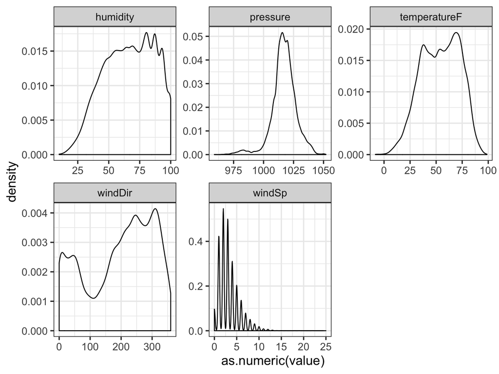

### Weekly running mean of the five weather features over 5 years

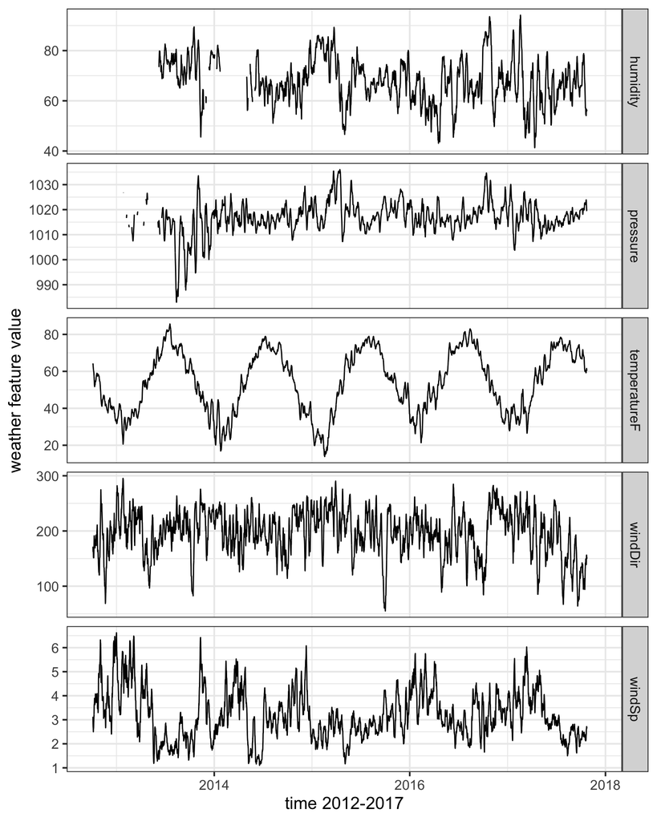

- As one would expect the longitudinal weather features shows seasonal patterns specailly for temperature. As I said earlier for true future weather forecasting problem the preferred approach will be timeseries based methods. However based on the langauge of this task I am assuming it is catered towards the use of classification/machine learning methods.

### Defining response variable for the problem

- **Rain (Yes/No)** - For binary classification. Based on the whether it rained at all on any given day. All weather description values *rain|thunder|drizzle* were convereted to rain.
- **Rain/Snow/Clear/Cloudy/Other** - For multiclass classfication the following conversion was used to create a response variable. However due to compute requirement for model training using the hourly data multiclass prediction was not pursued.

| Weather Description containing | Final Label |
| --- | --- |
| rain, thunder, drizzle | rain |
| cloud, fog , mist | cloudy |
| snow | snow |
| clear | clear |
| ALL OTHER | other |

### Feature(hourly) distribution faceted by whether it rained in that hour

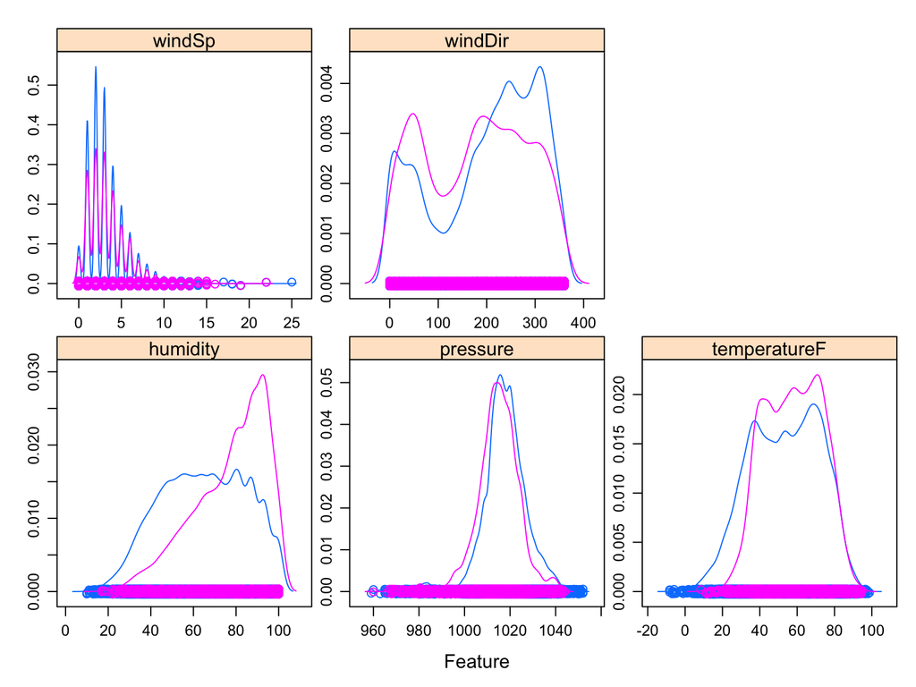

Looking at the data distribution it seems humidity should be the most important variable that can distinguish between rain and no-rain days.

### Feature Engineering

The following derived features were added to generate two data sets for machine learning

- By hour
  1. Season
  2. Week of year
  3. Month
- By Day - For each of the 5 weather features the following summary was generated per day
  1. Mean
  2. Median
  3. Interquartile
  4. Minimum and Maximum value on the day
  5. Standard deviation
  6. Average and SD change during the day
- By Time of Day - All daily features created above were further stratified by time of day